# index

## An Algebraic Approach to MaxCSP

**Ilario Bonacina**  
*UPC Barcelona Tech*

Jordi Levy  
*IIIA-CSIC*

Aug 15, 2025  
SAT’25, Glasgow, UK

Polynomial Calculus for MaxSAT/MaxCSP over multivalued domains:  
a proof-construction strategy.

MaxSAT/MaxCSP on polynomials

**Input**: a set of polynomials $P=\{p_1,\dots,p_m\}\subseteq \mathbb F[\vec x]$  
**Goal**: find the **maximum** # of $p_i$s with a common zero in $\mathbb F$  
(equivalently: find the **minimum** # $k_P$ of $p_i$ not set to zero)

Toy example 1

$P=\{\ 1+x,\qquad y,\qquad -x-y,\qquad x^2+1\ \}$

$P\subset \mathbb Q[x,y]$  
$k_P=\ ?$

$P\subset \mathbb F_3[x,y]$  
$k_P=\ ?$

$P\subset \mathbb F_4[x,y]$  
$k_P=\ ?$

Answers: 2, 2, 1

**This talk:**  
an algebraic system (/algorithm) to certify the correctness of $k_P$ but **only for finite fields**

What can we encode nicely?

- (Max)SAT instances can be encoded as sets of polynomials:
  $x\lor y\lor \lnot z$ $\to \{$ $\bar x \bar yz$$,\ x^2-x,\ y^2-y,\ z^2-z, 1-x-\bar x,1-y-\bar y, 1-z-\bar z\ \}$
- Some problems have **natural** non-Boolean encodings

3-COLORING  
*$G=(V,E)$ is 3-colorable*

$\Updownarrow$

$VC(G)=\{x_v^2+x_vx_w+x_w^2-1 \mid (v,w)\in E\}\subset \mathbb F_3[\vec x]$  
has a common zero.

**Theorem:** A set of polynomials $P$ has no common zeros (in an algebraically closed extension)

$\Updownarrow$

$1\in \langle P\rangle$

$\Updownarrow$

from $P$ using the inference rules $\quad\displaystyle\frac{p\quad q}{p+q}$ $\quad\displaystyle\frac{p}{pq}\quad$ we can derive $1$

In Polynomial Calculus $pq$ is written explicitly as a polynomial.

Polynomial Calculus:

- is behind Gröbner bases computations  
  (used in practice *e.g.* for verification of multiplier circuits, coloring of graphs, …)
- is connected with the quest for l.b.s for $AC_0[\oplus]$-Frege
- is stronger than Resolution  
  (with natural encoding, otherwise possibly incomparable [[Mouli’24]](https://doi.org/10.1109/FOCS61266.2024.00055))
- The strength (and understanding) of the system varies a lot
  - $\{0,1\}$-valued variables (somewhat understood)
  - $\{+1,-1\}$-valued (not-so understood)
  - $\{1,2\}$-valued (not a single size l.b.!!)
- can be adapted to work for MaxSAT [[Bonacina, Bonet, Levy SAT’23]](https://doi.org/10.1016/j.artint.2024.104208)

**Theorem ([[Bonacina, Bonet, Levy SAT’23]](https://doi.org/10.1016/j.artint.2024.104208)):** from a multiset $P\subset \mathbb F_2[\vec x]$ with cost $k_P$ over Boolean assignments, using the **substitution** rules

$$\displaystyle\frac{p\quad q}{p+q\quad pq\quad pq}$$

and

$$\displaystyle\frac{p}{pq\quad p(q-1)}$$

and

$$\displaystyle\frac{p}{q}\quad \text{if }p-q\in \langle x_1^2-x_1,\dots,x_n^2-x_n\rangle$$

we can obtain<sup>1</sup> a multiset containing $1$ with multiplicity $k_P$  
(and the remaining polynomials with a common zero)

[^1]: with a simple and sometimes efficient procedure

**Theorem ([[Bonacina, Bonet, Levy SAT’23]](https://doi.org/10.1016/j.artint.2024.104208)):** from a multiset $P\subset \mathbb F_\kappa[\vec x]$ with cost $k_P$ over Boolean assignments, using the **substitution** rules

$$\displaystyle\frac{p\quad q}{p+q\quad pq\quad p((p+q)^{\kappa-1}-1)}$$

and

$$\displaystyle\frac{p}{pq\quad p(q^{\kappa-1}-1)}$$

and

$$\displaystyle\frac{p}{q}\quad \text{if }p-q\in \langle x_1^2-x_1,\dots,x_n^2-x_n\rangle$$

we can obtain<sup>1</sup> a multiset containing $1$ with multiplicity $k_P$  
(and the remaining polynomials with a common zero)

[^2]: with a simple and sometimes efficient procedure

**Theorem (this work):** from a multiset $P\subset \mathbb F_\kappa[\vec x]$ with cost $k_P$ over assignments in $\mathbb F_\kappa$, using the **substitution** rules

$$\displaystyle\frac{p\quad q}{p+q\quad pq\quad p((p+q)^{\kappa-1}-1)}$$

and

$$\displaystyle\frac{p}{pq\quad p(q^{\kappa-1}-1)}$$

and
$$\displaystyle\frac{p}{q}\quad \text{if }p-q\in \langle x_1^\kappa-x_1,\dots,x_n^\kappa-x_n\rangle$$

we can obtain<sup>1</sup> a multiset containing $1$ with multiplicity $k_P$  
(and the remaining polynomials with a common zero)

[^3]: with a **somewhat** simple and sometimes efficient procedure

Toy example 1 — cont’d.  
$P\phantom{_1}=\{\ 1+x,\quad y,\quad -x-y,\quad x^2+1\ \}$ $\subset \mathbb F_3[x,y]$

$\displaystyle\frac{p}{q}\quad \text{if }p-q\in \langle x_1^3-x_1,\dots,x_n^3-x_n\rangle$

$\displaystyle\frac{p}{pq\quad p(q^2-1)}$

$\displaystyle\frac{p\quad q}{p+q\quad pq\quad p((p+q)^2-1)}$

$P_1=\{\ 1+x,\quad y, \quad -x-y, \quad (x^2+1)^2, \quad (x^2+1)((x^2+1)^2-1)\ \}$

$P_2=\{\ 1+x,\quad y, \quad -x-y, \quad 1\ \}$

$P_3=\{\ 1+x+y,\quad (1+x)y,\quad y((1+x+y)^2-1), \quad -x-y, \quad 1\ \}$

$P_4=\{\ 1,\quad (1+x+y)(-x-y),\quad (1+x)y,\quad y((1+x+y)^2-1), \quad 1\ \}$

$k_P=2$

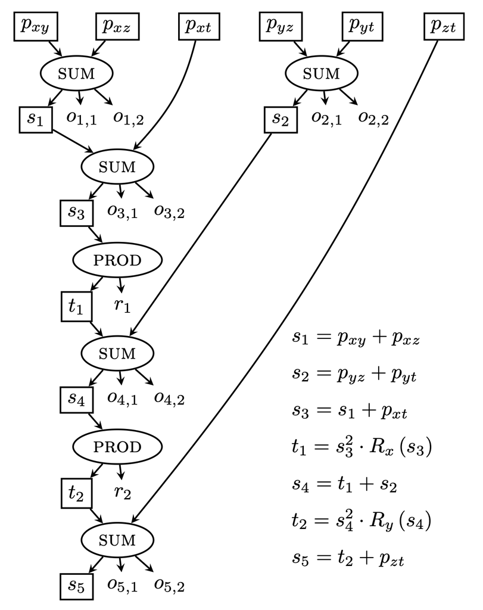

**Toy Example 2**  
A proof in the system that $K_4$ can be $3$-colored violating exactly one edge constraint.

$p_{uv}=x_u^2+x_ux_v+x_v^2-1\in \mathbb F_3[x_u,x_v]$

**Theorem (this work):** from a multiset $P\subset \mathbb F_\kappa[\vec x]$ with cost $k_P$ over assignments in $\mathbb F_\kappa$, using the **substitution** rules

$$\displaystyle\frac{p\quad q}{p+q\quad pq\quad p((p+q)^{\kappa-1}-1)}$$

and

$$\displaystyle\frac{p}{pq\quad p(q^{\kappa-1}-1)}$$

and
$$\displaystyle\frac{p}{q}\quad \text{if }p-q\in \langle x_1^\kappa-x_1,\dots,x_n^\kappa-x_n\rangle$$

we can obtain<sup>1</sup> a multiset containing $1$ with multiplicity $k_P$  
(and the remaining polynomials with a common zero)

[^4]: with a **somewhat** simple and sometimes efficient procedure

**Proof sketch** (for simplicity for $\mathbb F_3[x_1,\dots,x_n])$:

**Definition:** A set of polynomials $S$ is $x$-saturated if  
every assignment can be modified in just $x$ to an assignment satisfying the polynomials in $S$ depending on $x$.

Toy Example 3

- Is $\{\ 1+x,\ y,\ -x-y\ \}$ $y$-saturated?
- Is $\{1+x,xy, (x^2-1)(y-1)\}$ $y$-saturated?

Answers: No, Yes

**Main Lemma: (Non-trivial!)**
Let $R_x(p)$$\stackrel{def}=p|_{x=0}\cdot p|_{x=1}\cdot p|_{x=-1}$.
If for all polynomials $p_1,p_2,p_3\in S$ depending on $x$
$$\left.\begin{array}{l}
R_x(p_1)\\
R_x(p_1+p_2)\\
R_x(p_1-p_2)\\
R_x(p_1+p_2+p_3)\\
R_x(p_1-p_2-p_3)
\end{array}\right\}
\in \langle x_1^3-x_1,\dots,x_n^3-x_n\rangle$$
then $S$ is $x$-saturated.

**Lemma (saturation):** From $P$ it is possible to obtain efficiently *in the calculus* an $x$-saturated set of polynomials.

**A proof-contruction strategy** ($\sim$ [[Bonet, Levy, Manyà ’07]](https://doi.org/10.1016/j.artint.2007.03.001))

- saturate the initial polynomials $P$ w.r.t. $x_1$
- saturate the obtained polynomials non depending on $x_1$ w.r.t. $x_2$
- saturate the obtained polynomial non depending on $x_2$ w.r.t. $x_3$
- …
- in the end:
  - $\ell$ polynomials not depending on any variables (*i.e. non-zero constants*)
  - and the Main Lemma ensures the rest of polynomials are satisfiable,  
    hence $\ell=k_P$. $\qquad\qquad\qquad\qquad\qquad\qquad\qquad\qquad\qquad\qquad$🍉

## Thanks!

- Our work shows completeness of MaxCSP Polynomial Calculus on multivalued variables
- Might be useful in cases when Gröbner bases computations are useful in practice (future work)
- Open: MaxCSP Polynomial Calculus on char 0 fields or rings with zero-divisors

Polynomial Calculus for MaxSAT/MaxCSP over multivalued domains:  
a proof-construction strategy.

This work was funded by AEI grants PID2022-138506NB-C21 and PID2022-138506NB-C22.